# IE48A Assignment2 - Electricity Market Prices

Berkay Zühre

8/24/2020

## Introduction

In this assignment hourly Electricity Market Prices between 01/07/2020 and 31/07/2020 are analyzed. Electricity should be consumed as it is produced, so the production should be equal to the consumption as much as possible. I mainly used dplyr and ggplot packages to analyze the data.

I called the packages I might need here then read the data.

```r
library(dplyr)
library(ggplot2)
library(lubridate)
library(tidyr)
```

```r
data = read.csv("C:/Users/zuhre.b/OneDrive - Procter and Gamble/Desktop/electricityMarketPrice.csv")
```

Lets have a look at the data.

```r
head(data,5)
```

```
##            Tarih    PTF    SMF Pozitif.Dengesizlik.Fiyatý..TL.MWh.
## 1 01.07.20 00:00 323,85 211,00                              204,67
## 2 01.07.20 01:00 326,95 201,00                              194,97
## 3 01.07.20 02:00 324,31 211,00                              204,67
## 4 01.07.20 03:00 322,11 211,00                              204,67
## 5 01.07.20 04:00 320,00 201,00                              194,97
##   Negatif.Dengesizlik.Fiyatý..TL.MWh.         SMF.Yön
## 1                              333,57 ?Enerji Fazlasý
## 2                              336,76 ?Enerji Fazlasý
## 3                              334,04 ?Enerji Fazlasý
## 4                              331,77 ?Enerji Fazlasý
## 5                              329,60 ?Enerji Fazlasý
```

```r
summary(data)
```

```
##     Tarih               PTF                SMF
##  Length:744         Length:744         Length:744
##  Class :character   Class :character   Class :character
##  Mode  :character   Mode  :character   Mode  :character
##  Pozitif.Dengesizlik.Fiyatý..TL.MWh. Negatif.Dengesizlik.Fiyatý..TL.MWh.
##  Length:744                          Length:744
##  Class :character                    Class :character
##  Mode  :character                    Mode  :character
##    SMF.Yön
##  Length:744
##  Class :character
##  Mode  :character
```

```r
glimpse(data)
```

```
## Rows: 744
## Columns: 6
## $ Tarih                               <chr> "01.07.20 00:00", "01.07.20 01:...
## $ PTF                                 <chr> "323,85", "326,95", "324,31", "...
## $ SMF                                 <chr> "211,00", "201,00", "211,00", "...
## $ Pozitif.Dengesizlik.Fiyatý..TL.MWh. <chr> "204,67", "194,97", "204,67", "...
## $ Negatif.Dengesizlik.Fiyatý..TL.MWh. <chr> "333,57", "336,76", "334,04", "...
## $ SMF.Yön                             <chr> "?Enerji Fazlasý", "?Enerji Faz...
```

The main problems seen from above are the data types and column names.

```r
data[,1]= as.POSIXct(factor(data[,1]), format="%d.%m.%y %H:%M")
data[,2] = as.numeric(gsub(",", ".", data[,2]))
data[,3] = as.numeric(gsub(",", ".", data[,3]))
data[,4] = as.numeric(gsub(",", ".", data[,4]))
data[,5] = as.numeric(gsub(",", ".", data[,5]))
data[,6]=as.factor(data[,6])
colnames(data)=c("Date","MSP","SMP","PosBalance","NegBalance","Direction")
data$Day=day(data$Date)
data$Hour=hour(data$Date)
glimpse(data)
```

```
## Rows: 744
## Columns: 8
## $ Date       <dttm> 2020-07-01 00:00:00, 2020-07-01 01:00:00, 2020-07-01 02...
## $ MSP        <dbl> 323.85, 326.95, 324.31, 322.11, 320.00, 286.21, 210.13, ...
## $ SMP        <dbl> 211.00, 201.00, 211.00, 211.00, 201.00, 181.00, 113.75, ...
## $ PosBalance <dbl> 204.67, 194.97, 204.67, 204.67, 194.97, 175.57, 110.34, ...
## $ NegBalance <dbl> 333.57, 336.76, 334.04, 331.77, 329.60, 294.80, 216.43, ...
## $ Direction  <fct> ?Enerji Fazlasý, ?Enerji Fazlasý, ?Enerji Fazlasý, ?Ener...
## $ Day        <int> 1, 1, 1, 1, 1, 1, 1, 1, 1, 1, 1, 1, 1, 1, 1, 1, 1, 1, 1,...
## $ Hour       <int> 0, 1, 2, 3, 4, 5, 6, 7, 8, 9, 10, 11, 12, 13, 14, 15, 16...
```

I plot the two values against each other at first to see their relationships in a better way. It can be seen that there is a weak linear relationship meaning as MSP goes up SMP goes up as well. That is probably related to the increased prices at the end of the month. However for MSP value interval 300-325 there is wide spectrum of values for SMP with high density. We can also see that MSP has a lower variance compared to SMP.

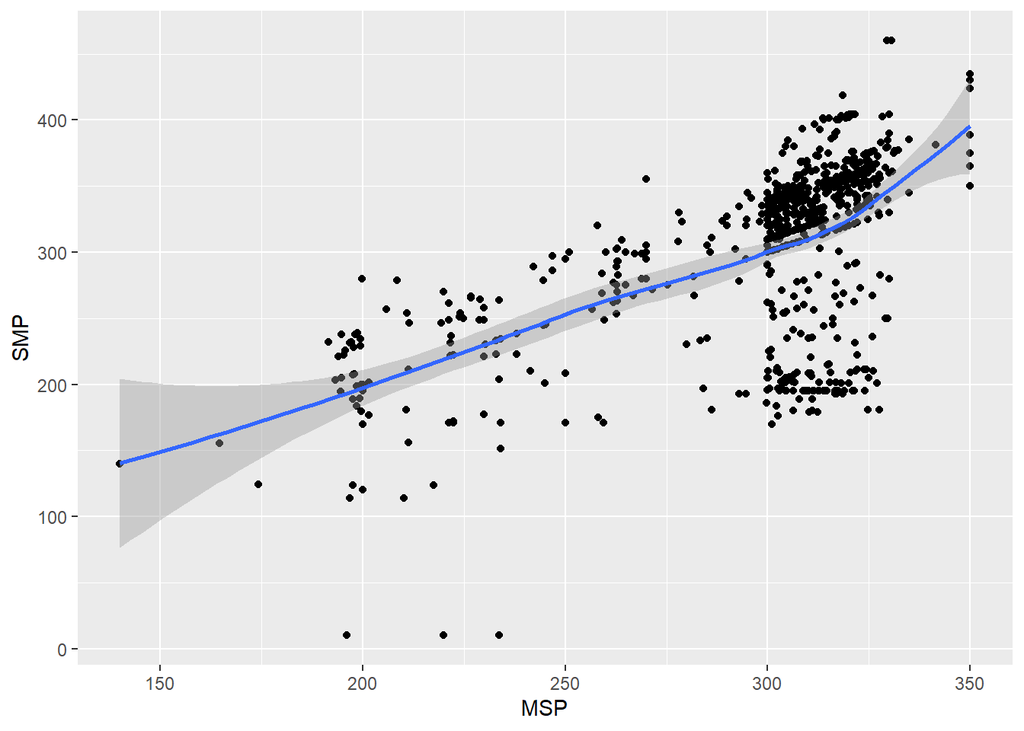

```r
ggplot(data, aes(x=MSP, y=SMP)) + geom_point() + geom_smooth()
```

```r
total <- merge(data %>% group_by(Day) %>% dplyr::summarize(Mean = mean(MSP, na.rm=TRUE)),data %>% group_by(Day) %>% dplyr::summarize(Mean = mean(SMP, na.rm=TRUE)),by="Day")
```

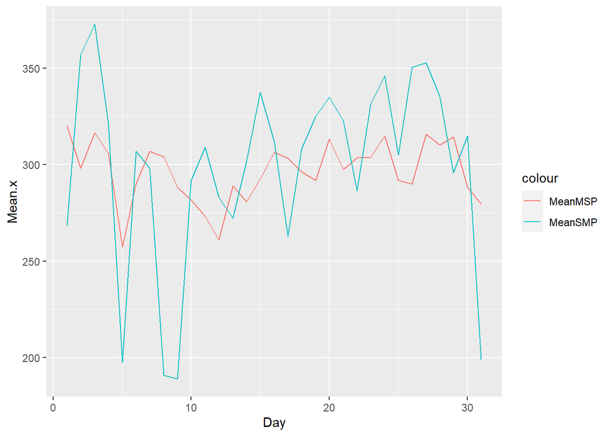

```r
ggplot(total, aes(Day)) +
  geom_line(aes(y = Mean.x, colour = "MeanMSP")) +
  geom_line(aes(y = Mean.y, colour = "MeanSMP"))
```

I applied the same approach here, only difference is that I grouped the data by hours. It can be seen that early in the morning prices are at the lowest levels because demand is low. In the evenings demand is the highest so the prices go up.

```r
total2 <- merge(data %>% group_by(Hour) %>% dplyr::summarize(Mean = mean(MSP, na.rm=TRUE)),data %>% group_by(Hour) %>% dplyr::summarize(Mean = mean(SMP, na.rm=TRUE)),by="Hour")
```

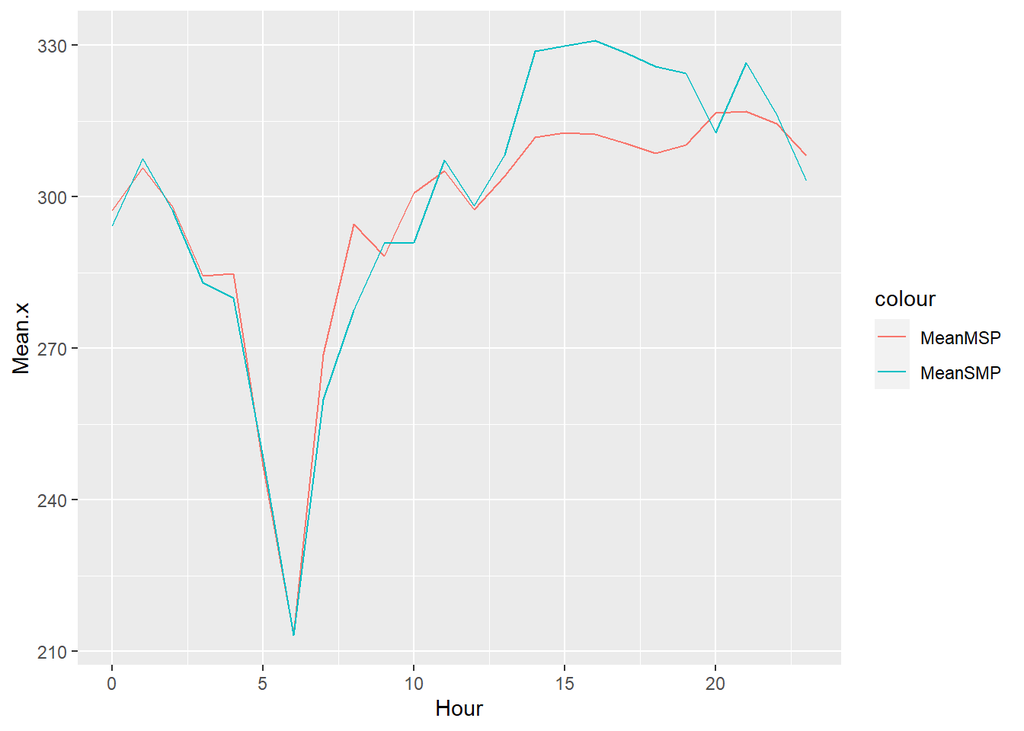

```r
ggplot(total2, aes(Hour)) +
  geom_line(aes(y = Mean.x, colour = "MeanMSP")) +
  geom_line(aes(y = Mean.y, colour = "MeanSMP"))
```